# Kaggle Project

Mehul Patel

November 3, 2017

### In this competition, you will predict the probability that an auto insurance policy holder files a claim.

### In the train and test data, features that belong to similar groupings are tagged as such in the feature names (e.g., ind, reg, car, calc). In addition, feature names include the postfix bin to indicate binary features and cat to indicate categorical features. Features without these designations are either continuous or ordinal.

### Values of -1 indicate that the feature was missing from the observation. The target columns signifies whether or not a claim was filed for that policy holder.

```r
library(pROC)  ## For AUC and ROC
library(randomForest)  ## For RandomForest Algorithm
library(caret)  ## For ConfusionMatrix
library(e1071, quietly = T)  ## For NaiveBayes
library(dplyr, quietly = T)  ## For data manipulation and cleaning
```

```r
library(reshape2, quietly = T)  ## Reshaping data frames and then use it for plotting
library(ggplot2, quietly = T)  ## Plotting the data
library(stringr, quietly = T) ## Data cleaning and string manipulaitons
# train <- read.csv('C:\\Users\\mpatel\\Documents\\MP_Personal\\7275_DataMining\\Project\\Kaggle_Data\\train.csv', nrows = 100000)

train <- read.csv('C:\\Users\\mpatel\\Documents\\MP_Personal\\7275_DataMining\\Project\\Kaggle_Data\\train.csv')

glimpse(train)
```

```
## Observations: 595,212
## Variables: 59
## $ id             <int> 7, 9, 13, 16, 17, 19, 20, 22, 26, 28, 34, 35, 3...
## $ target         <int> 0, 0, 0, 0, 0, 0, 0, 0, 0, 1, 0, 0, 0, 0, 0, 0,...
## $ ps_ind_01      <int> 2, 1, 5, 0, 0, 5, 2, 5, 5, 1, 5, 2, 2, 1, 5, 5,...
## $ ps_ind_02_cat  <int> 2, 1, 4, 1, 2, 1, 1, 1, 1, 1, 2, 1, 1, 1, 1, 1,...
## $ ps_ind_03      <int> 5, 7, 9, 2, 0, 4, 3, 4, 3, 2, 2, 3, 1, 3, 11, 3...
## $ ps_ind_04_cat  <int> 1, 0, 1, 0, 1, 0, 1, 0, 1, 0, 0, 1, 1, 1, 0, 1,...
## $ ps_ind_05_cat  <int> 0, 0, 0, 0, 0, 0, 0, 0, 0, 0, 0, 0, 0, 0, 0, 0,...
## $ ps_ind_06_bin  <int> 0, 0, 0, 1, 1, 0, 0, 1, 0, 0, 0, 0, 0, 0, 0, 0,...
## $ ps_ind_07_bin  <int> 1, 0, 0, 0, 0, 0, 1, 0, 0, 1, 0, 1, 0, 1, 0, 1,...
## $ ps_ind_08_bin  <int> 0, 1, 1, 0, 0, 0, 0, 0, 1, 0, 1, 0, 1, 0, 0, 0,...
## $ ps_ind_09_bin  <int> 0, 0, 0, 0, 0, 1, 0, 0, 0, 0, 0, 0, 0, 0, 1, 0,...
## $ ps_ind_10_bin  <int> 0, 0, 0, 0, 0, 0, 0, 0, 0, 0, 0, 0, 0, 0, 0, 0,...
## $ ps_ind_11_bin  <int> 0, 0, 0, 0, 0, 0, 0, 0, 0, 0, 0, 0, 0, 0, 0, 0,...
```

[output cut: 46 more lines]

> Plotting Data: Distribution of target variable seems highly skewed. Only ~3.6% of total observations seem to have positive response.

```r
table(train$target)
```

```
##
##      0      1
## 573518  21694
```

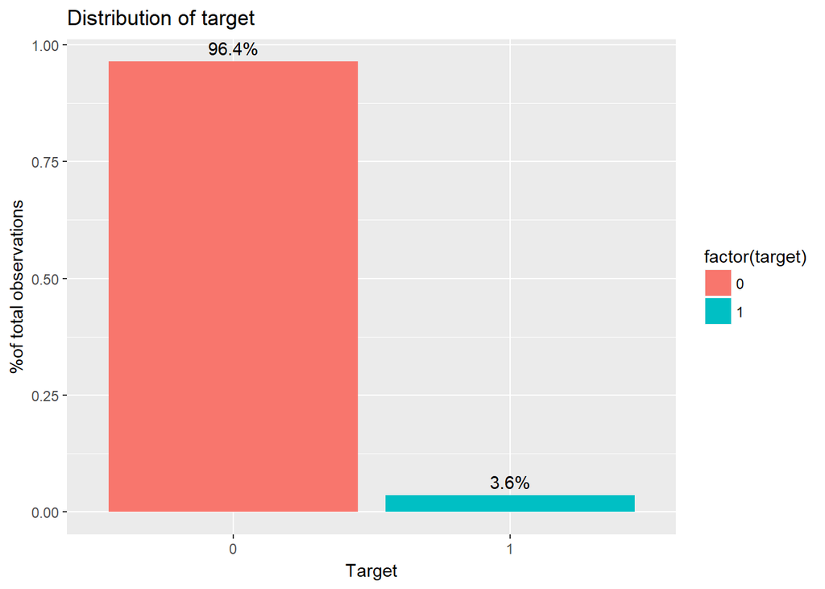

```r
ggplot(data = train, aes(x = factor(target))) +
  geom_bar(stat = 'count', aes(y = (..count..)/sum(..count..), fill = factor(target))) +
  geom_text(aes(y = (..count..)/sum(..count..),
                label = scales::percent((..count..)/sum(..count..))),
            stat = 'count', vjust = -0.5) +
  labs(y = '%of total observations', x = 'Target', title = 'Distribution of target')
```

```r
## Feature Engineering: Converting '*_cat' and '*_bin' variables into factor:

## Getting column names of binary and categorical variables:
cat_bin_cols <- train %>%
                select(contains('cat'), contains('bin')) %>%
                colnames()
train[cat_bin_cols] <- lapply(train[cat_bin_cols], factor)
glimpse(train)
```

```
## Observations: 595,212
## Variables: 59
## $ id             <int> 7, 9, 13, 16, 17, 19, 20, 22, 26, 28, 34, 35, 3...
## $ target         <int> 0, 0, 0, 0, 0, 0, 0, 0, 0, 1, 0, 0, 0, 0, 0, 0,...
## $ ps_ind_01      <int> 2, 1, 5, 0, 0, 5, 2, 5, 5, 1, 5, 2, 2, 1, 5, 5,...
## $ ps_ind_02_cat  <fctr> 2, 1, 4, 1, 2, 1, 1, 1, 1, 1, 2, 1, 1, 1, 1, 1...
## $ ps_ind_03      <int> 5, 7, 9, 2, 0, 4, 3, 4, 3, 2, 2, 3, 1, 3, 11, 3...
## $ ps_ind_04_cat  <fctr> 1, 0, 1, 0, 1, 0, 1, 0, 1, 0, 0, 1, 1, 1, 0, 1...
## $ ps_ind_05_cat  <fctr> 0, 0, 0, 0, 0, 0, 0, 0, 0, 0, 0, 0, 0, 0, 0, 0...
## $ ps_ind_06_bin  <fctr> 0, 0, 0, 1, 1, 0, 0, 1, 0, 0, 0, 0, 0, 0, 0, 0...
## $ ps_ind_07_bin  <fctr> 1, 0, 0, 0, 0, 0, 1, 0, 0, 1, 0, 1, 0, 1, 0, 1...
## $ ps_ind_08_bin  <fctr> 0, 1, 1, 0, 0, 0, 0, 0, 1, 0, 1, 0, 1, 0, 0, 0...
## $ ps_ind_09_bin  <fctr> 0, 0, 0, 0, 0, 1, 0, 0, 0, 0, 0, 0, 0, 0, 1, 0...
## $ ps_ind_10_bin  <fctr> 0, 0, 0, 0, 0, 0, 0, 0, 0, 0, 0, 0, 0, 0, 0, 0...
## $ ps_ind_11_bin  <fctr> 0, 0, 0, 0, 0, 0, 0, 0, 0, 0, 0, 0, 0, 0, 0, 0...
```

[output cut: 46 more lines]

```r
## Getting column names of continuous variables:
oth_col_vec <- colnames(train) %>%
               setdiff(cat_bin_cols)
train_cont_df <- train[oth_col_vec]
```

> Creating three small dataframes with 10-11 categorical variables to check their distributions. This visuals will also help in determining how the missing values should be treated.

```r
train_cat_1 <- train[cat_bin_cols[1:10]] %>%
  mutate(target = train$target)
target_3 <- factor(melt(train_cat_1, id.vars = 'target')$target)
```

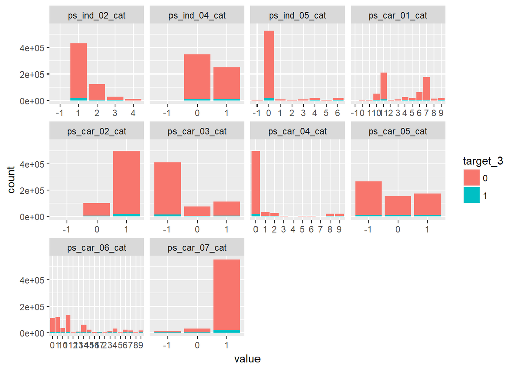

```r
ggplot(data = melt(train_cat_1, id.vars = 'target'), aes(x = value)) +
  geom_bar(aes(fill = target_3)) +
  facet_wrap(~variable, scales = 'free_x', nrow = 3, ncol = 4)
```

```r
rm(train_cat_1)


train_cat_2 <- train[cat_bin_cols[11:20]] %>%
  mutate(target = train$target)
target_4 <- factor(melt(train_cat_2, id.vars = 'target')$target)
```

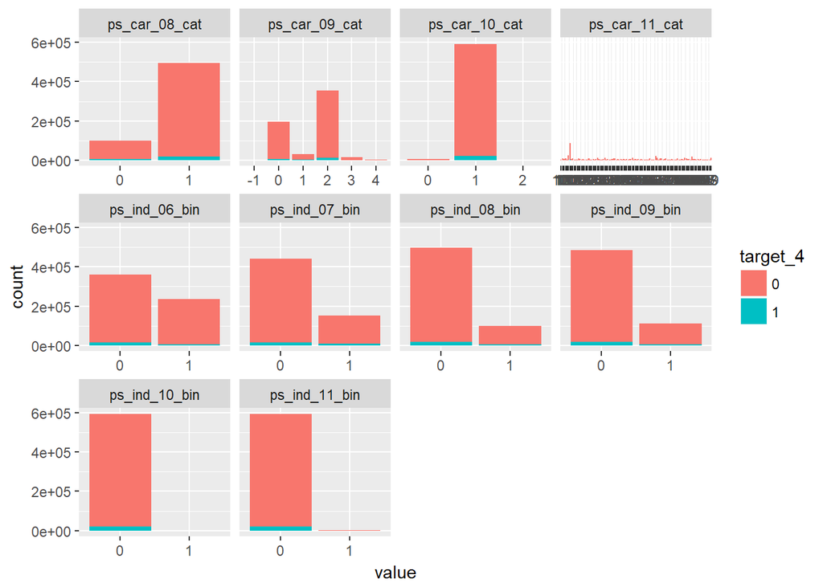

```r
ggplot(data = melt(train_cat_2, id.vars = 'target'), aes(x = value)) +
  geom_bar(aes(fill = target_4)) +
  facet_wrap(~variable, scales = 'free_x')
```

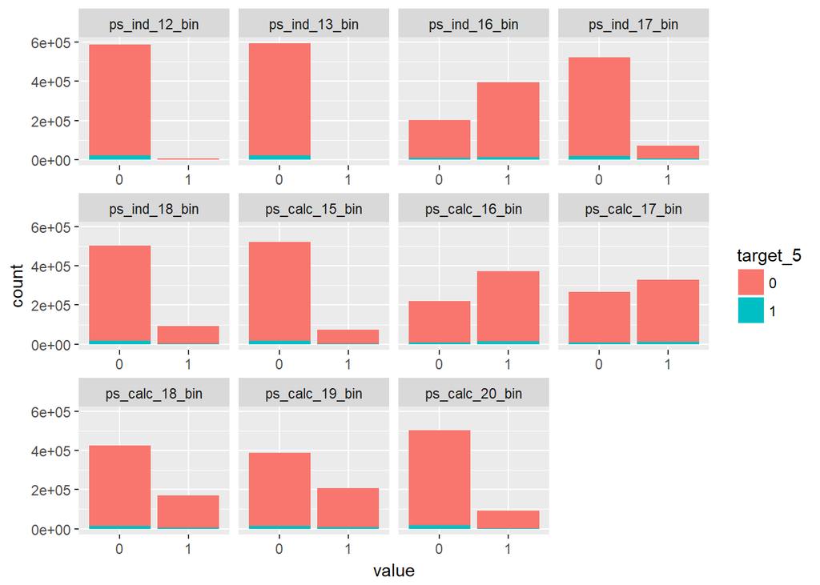

```r
rm(train_cat_2)


train_cat_3 <- train[cat_bin_cols[21:length(cat_bin_cols)]] %>%
  mutate(target = train$target)
target_5 <- factor(melt(train_cat_3, id.vars = 'target')$target)
ggplot(data = melt(train_cat_3, id.vars = 'target'), aes(x = value)) +
  geom_bar(aes(fill = target_5)) +
  facet_wrap(~variable, scales = 'free_x')
```

```r
rm(train_cat_3)
```

> Following heatmap will help help us in understading the correlation among various continuous variables.

> There is a couple of ‘car’ and ‘region’ related variables which seem to have strong-positive correlation but for now I’ll keep them as they are.

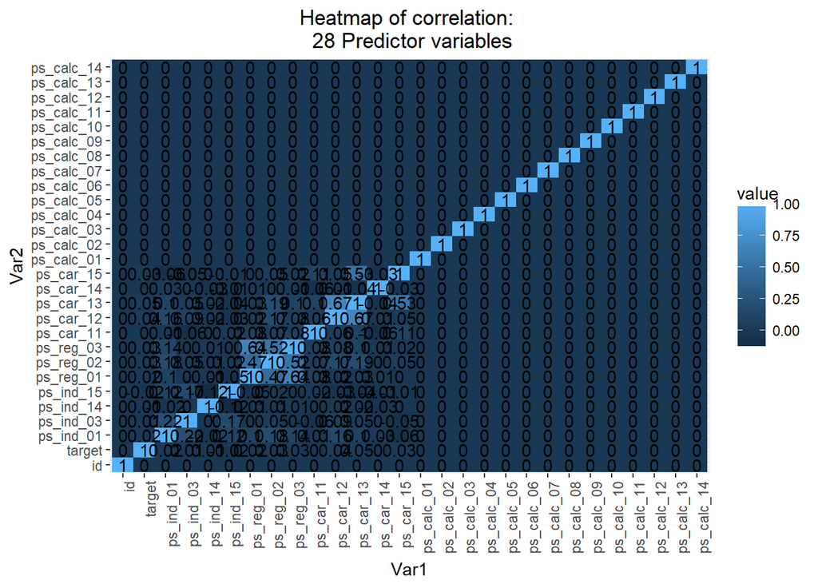

```r
## Heatmap of correlation:
train_cont_cor <- round(cor(train_cont_df), 2) %>%
                melt()

ggplot(train_cont_cor, aes(x = Var1, y = Var2, fill = value)) +
  geom_tile() +
  # scale_fill_gradient(low = 'white', high = 'black') +
  geom_text(aes(label = value)) +
  ggtitle('Heatmap of correlation: \n 28 Predictor variables') +
  theme(plot.title = element_text(hjust = 0.5), axis.text.x = element_text(angle = 90, hjust = 1))
```

```r
  # theme(axis.text.x = element_text(angle = 90, hjust = 1))
```

> Following histograms of continuous variables help us in understanding how continuous variables are distributed, and that can be utilized while dealing with missing values.

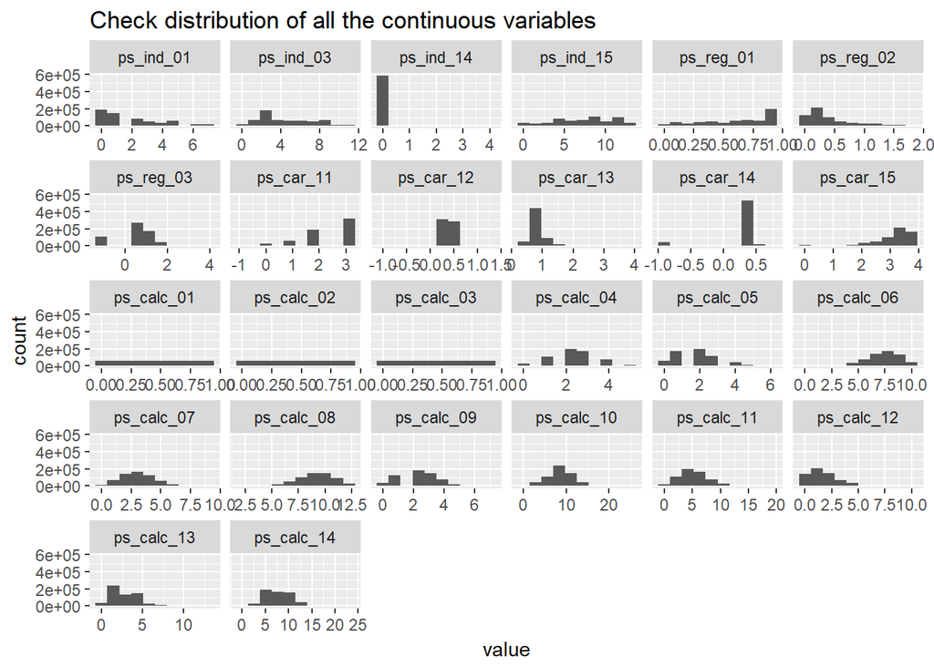

```r
## Checking distribution of continuous variables:
ggplot(data = melt(train_cont_df[,3:dim(train_cont_df)[2]]), mapping = aes(x = value)) +
  geom_histogram(bins = 10) +
  facet_wrap(~variable, scales = 'free_x') +
  ggtitle('Check distribution of all the continuous variables')
```

> Output of following chunk gives number of missing values in each column of the training dataframe. In the o/p, ignore the ‘-1’ at the end of the names of columns.

> There are total of 13 variables which have missing values. Out of them, 4 are continuous and remaining are categorical. We don’t have any binary feature whihc has missing values.

```r
get_missing <- function(x){
  groups <- table(x)
  count <- groups[names(groups) == '-1']
  return (count)
}

missing_vals <- sapply(train,  FUN = get_missing)
unlist(missing_vals)
```

```
## ps_ind_02_cat.-1 ps_ind_04_cat.-1 ps_ind_05_cat.-1     ps_reg_03.-1
##              216               83             5809           107772
## ps_car_01_cat.-1 ps_car_02_cat.-1 ps_car_03_cat.-1 ps_car_05_cat.-1
##              107                5           411231           266551
## ps_car_07_cat.-1 ps_car_09_cat.-1     ps_car_11.-1     ps_car_12.-1
##            11489              569                5                1
##     ps_car_14.-1
##            42620
```

> Checking proportions of various categories in categorical variables which have missing values.

> Feature ‘ps_car_03_cat’ and ‘ps_car_05_cat’ have ~69% and ~45% missing values which is not good! For the remaining of the features, proportion of missing values is not significant. So, we can replace the ‘-1’ with the most frequent (or prevalent) category for those variables.

```r
cols <- names(unlist(missing_vals))

modify_col_names <- function(x){
  sub_cols <- character()
  for (i in cols){
    temp_col <- unlist(str_split(i, pattern = '\\.'))[1]
    sub_cols <- append(sub_cols, temp_col)

    last <- tail(unlist(str_split(string = temp_col, pattern = '_')), 1)
    if (last == 'cat' | last == 'bin'){
      print (temp_col)
      show(prop.table(table(train[temp_col])))
    }
  }
}

modify_col_names(cols)
```

```
## [1] "ps_ind_02_cat"
##
##           -1            1            2            3            4
## 0.0003628959 0.7255549283 0.2076117417 0.0473545560 0.0191158780
## [1] "ps_ind_04_cat"
##
##           -1            0            1
## 0.0001394461 0.5829267555 0.4169337984
## [1] "ps_ind_05_cat"
##
##          -1           0           1           2           3           4
## 0.009759548 0.887094010 0.013981573 0.007029428 0.013832046 0.030819271
##           5           6
## 0.002770441 0.034713682
## [1] "ps_car_01_cat"
##
##           -1            0            1            2            3
## 0.0001797679 0.0099191549 0.0022966607 0.0036020779 0.0111859304
##            4            5            6            7            8
## 0.0439742478 0.0304798962 0.1048248355 0.3011481623 0.0253573517
##            9           10           11
## 0.0341441369 0.0841498491 0.3487379287
## [1] "ps_car_02_cat"
##
##           -1            0            1
## 8.400368e-06 1.700520e-01 8.299396e-01
## [1] "ps_car_03_cat"
##
##        -1         0         1
## 0.6908984 0.1231024 0.1859993
## [1] "ps_car_05_cat"
##
##        -1         0         1
## 0.4478253 0.2620814 0.2900933
## [1] "ps_car_07_cat"
##
##         -1          0          1
## 0.01930237 0.05136825 0.92932938
## [1] "ps_car_09_cat"
##
##           -1            0            1            2            3
## 0.0009559619 0.3268045671 0.0488565419 0.5938757955 0.0247911668
##            4
## 0.0047159667
```

```r
 ## Remove above mentioned two columns: 'ps_car_03_cat' and 'ps_car_05_cat'.
train <- train[,-c(26, 28)]

## Replace -1s with the most frequent category for respective variables, that is replace -1 with mode of the column:
train$ps_ind_02_cat[train$ps_ind_02_cat == -1] <- 1
prop.table(table(train$ps_ind_02_cat))
```

```
##
##         -1          1          2          3          4
## 0.00000000 0.72591782 0.20761174 0.04735456 0.01911588
```

```r
train$ps_ind_04_cat[train$ps_ind_04_cat == -1] <- 0
prop.table(table(train$ps_ind_04_cat))
```

```
##
##        -1         0         1
## 0.0000000 0.5830662 0.4169338
```

```r
train$ps_ind_05_cat[train$ps_ind_05_cat == -1] <- 0
prop.table(table(train$ps_ind_05_cat))
```

```
##
##          -1           0           1           2           3           4
## 0.000000000 0.896853558 0.013981573 0.007029428 0.013832046 0.030819271
##           5           6
## 0.002770441 0.034713682
```

```r
train$ps_car_01_cat[train$ps_car_01_cat == -1] <- 11
prop.table(table(train$ps_car_01_cat))
```

```
##
##          -1           0           1           2           3           4
## 0.000000000 0.009919155 0.002296661 0.003602078 0.011185930 0.043974248
##           5           6           7           8           9          10
## 0.030479896 0.104824836 0.301148162 0.025357352 0.034144137 0.084149849
##          11
## 0.348917697
```

```r
train$ps_car_02_cat[train$ps_car_02_cat == -1] <- 1
prop.table(table(train$ps_car_02_cat))
```

```
##
##       -1        0        1
## 0.000000 0.170052 0.829948
```

```r
train$ps_car_07_cat[train$ps_car_07_cat == -1] <- 1
prop.table(table(train$ps_car_07_cat))
```

```
##
##         -1          0          1
## 0.00000000 0.05136825 0.94863175
```

```r
train$ps_car_09_cat[train$ps_car_09_cat == -1] <- 2
prop.table(table(train$ps_car_09_cat))
```

```
##
##          -1           0           1           2           3           4
## 0.000000000 0.326804567 0.048856542 0.594831757 0.024791167 0.004715967
```

> Dealing with missing values of continuous or numeric variables: Numeric columns: ps_car_11 and ps_car_12 have very less number of missing values, 5 and 1 respectively.

> Numeric columns: ps_reg_03 and ps_car_14 have relative large number of missing values, 107772 and 42620 respectively.

> Based on summary statistics and distribution of this column, I’ll replace the missing values with mean of the column.

```r
## For mean based insertions, I remove the -1 from the columns and then find the mean. Otherwise -1 will decrease the value of the mean.
summary(train$ps_reg_03)
```

```
##    Min. 1st Qu.  Median    Mean 3rd Qu.    Max.
## -1.0000  0.5250  0.7207  0.5511  1.0000  4.0379
```

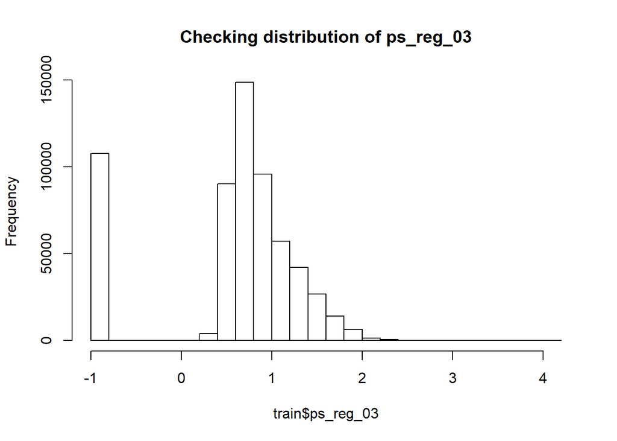

```r
hist(train$ps_reg_03, main = 'Checking distribution of ps_reg_03')
```

```r
mean_ps_reg_03 <- filter(train, ps_reg_03 != -1) %>%
                  select(ps_reg_03) %>%
                  colMeans()
train$ps_reg_03[train$ps_reg_03 == -1] <- mean_ps_reg_03

mean_ps_car_14 <- filter(train, ps_car_14 != -1) %>%
                  select(ps_car_14) %>%
                  colMeans()
train$ps_car_14[train$ps_car_14 == -1] <- mean_ps_car_14


## Following continuous columns have very less missing values, 5 and 1 respectively:
mean_ps_car_11 <- filter(train, ps_car_11 != -1) %>%
                  select(ps_car_11) %>%
                  colMeans()
train$ps_car_11[train$ps_car_11 == -1] <- mean_ps_car_11

mean_ps_car_12 <- filter(train, ps_car_12 != -1) %>%
                  select(ps_car_12) %>%
                  colMeans()
train$ps_car_12[train$ps_car_12 == -1] <- mean_ps_car_12
```

> At the beginning of the script - in the very first plot, we saw that target is disproportionately distributed. So, if we don’t provide enough of two classes of target to the model, then model may not be able to learn the characteristics of either of the classes, and may end up with poor overall performance.

> To remedy this, we’ll oversample the ‘rare occurrences’ of the target in the training set, and that is occurrences of class-1. However, while making predictions, we’ll use entire training set in which the distribution of target will be disproportionate.

> Size of the training set will be ~30k, and split will be 60:40<–>class_0:class_1

```r
## Splitting data into '0' and '1', and then taking random samples to create a training set.
train_2 <- train[-1]  ## Removing ID column
train_2_0 <- filter(train_2, target == 0)
train_2_1 <- filter(train_2, target == 1)

set.seed(11)
train_set <- sample_n(train_2_0, size = 18000)
train_set <- train_2_1 %>%
            sample_frac(size = 0.55) %>%
            rbind(train_set)

rm(train_2_0)  ; rm(train_2_1); rm(train)
```

```r
## Fitting the NaiveBayes model:
nb_1 <- naiveBayes(as.factor(target)~., data = train_set)
class(nb_1)
```

```
## [1] "naiveBayes"
```

```r
## Predictions will be made on the entire training set:
pred_1 <- predict(nb_1, newdata = train_2[-1])
confusionMatrix(as.factor(train_2$target), pred_1)
```

```
## Confusion Matrix and Statistics
##
##           Reference
## Prediction      0      1
##          0 438732 134786
##          1  13630   8064
##
##                Accuracy : 0.7507
##                  95% CI : (0.7495, 0.7517)
##     No Information Rate : 0.76
##     P-Value [Acc > NIR] : 1
##
##                   Kappa : 0.0371
##  Mcnemar's Test P-Value : <2e-16
##
##             Sensitivity : 0.96987
##             Specificity : 0.05645
##          Pos Pred Value : 0.76498
##          Neg Pred Value : 0.37172
##              Prevalence : 0.76000
##          Detection Rate : 0.73710
##    Detection Prevalence : 0.96355
##       Balanced Accuracy : 0.51316
##
##        'Positive' Class : 0
##
```

```r
## There are few outliers in some of the continuos variables. So, now I'll insert median, instead of mean, for the missing values of the continuous variables:

med_ps_reg_03 <- filter(train_2, ps_reg_03 != -1) %>%
                select(ps_reg_03) %>%
                summarise(median = median(ps_reg_03))
train_2$ps_reg_03[train_2$ps_reg_03 == -1] <- med_ps_reg_03
train_2$ps_reg_03 <- as.numeric(train_2$ps_reg_03)

med_ps_car_14 <- filter(train_2, ps_car_14 != -1) %>%
                  select(ps_car_14) %>%
                  summarise(median = median(ps_car_14))
train_2$ps_car_14[train_2$ps_car_14 == -1] <- med_ps_car_14
train_2$ps_car_14 <- as.numeric(train_2$ps_car_14)
```

```r
train_2_0 <- filter(train_2, target == 0)
train_2_1 <- filter(train_2, target == 1)

set.seed(11)
train_set <- sample_n(train_2_0, size = 18000)
train_set <- train_2_1 %>%
            sample_frac(size = 0.55) %>%
            rbind(train_set)

rm(train_2_0); rm(train_2_1)

nb_2 <- naiveBayes(as.factor(target)~., data = train_set)
class(nb_2)
```

```
## [1] "naiveBayes"
```

```r
pred_2 <- predict(nb_2, newdata = train_2[-1])
confusionMatrix(as.factor(train_2$target), pred_2)
```

```
## Confusion Matrix and Statistics
##
##           Reference
## Prediction      0      1
##          0 438732 134786
##          1  13630   8064
##
##                Accuracy : 0.7507
##                  95% CI : (0.7495, 0.7517)
##     No Information Rate : 0.76
##     P-Value [Acc > NIR] : 1
##
##                   Kappa : 0.0371
##  Mcnemar's Test P-Value : <2e-16
##
##             Sensitivity : 0.96987
##             Specificity : 0.05645
##          Pos Pred Value : 0.76498
##          Neg Pred Value : 0.37172
##              Prevalence : 0.76000
##          Detection Rate : 0.73710
##    Detection Prevalence : 0.96355
##       Balanced Accuracy : 0.51316
##
##        'Positive' Class : 0
##
```

> From the confusion matrix, we see that mean based insertions and median based insertions produce almost the same results.

> NaiveBayes does not produce good results even on the training set. In this data, one of the classes, that is class-1, is more important than the other class. So, evaluating the performance of the model using accuracy is not the best idea.

> To identify class-1 more, the specificity of the model needs to be very high.

> Now, we’ll test how RandomForest algorithm works with this data.

```r
set.seed(101)
train_set_temp <- subset(x = train_set, select = -ps_car_11_cat)
# rf1 <- randomForest(as.factor(target)~., data = train_set_temp, mtry = 5)

## Remove this columns temporarily as it has more than 53 categories. Current implementation of RandomForest cannot handle more than 53 categories.
train_2_temp <- subset(x = train_2, select = -ps_car_11_cat)


rf3 <- randomForest(as.factor(target)~., data = train_set_temp, keep.forest = TRUE)
predicted_class <- predict(rf3, newdata = train_2_temp[-1])
predicted_prob <- predict(rf3, newdata = train_2_temp[-1], type = 'prob')

confusionMatrix(data = predicted_class, reference = train_2_temp$target)
```

```
## Confusion Matrix and Statistics
##
##           Reference
## Prediction      0      1
##          0 493369   7066
##          1  80149  14628
##
##                Accuracy : 0.8535
##                  95% CI : (0.8526, 0.8544)
##     No Information Rate : 0.9636
##     P-Value [Acc > NIR] : 1
##
##                   Kappa : 0.204
##  Mcnemar's Test P-Value : <2e-16
##
##             Sensitivity : 0.8603
##             Specificity : 0.6743
##          Pos Pred Value : 0.9859
##          Neg Pred Value : 0.1543
##              Prevalence : 0.9636
##          Detection Rate : 0.8289
##    Detection Prevalence : 0.8408
##       Balanced Accuracy : 0.7673
##
##        'Positive' Class : 0
##
```

```r
AUC <- auc(response = train_2_temp$target, predictor = predicted_prob[,2])
AUC
```

```
## Area under the curve: 0.8377
```

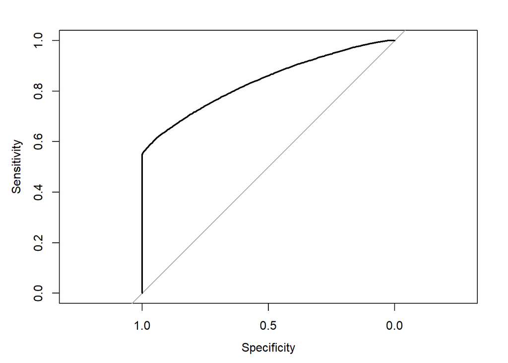

```r
plot(roc(train_2_temp$target, predicted_prob[,2]))
```